# 03_T-test

## Chapter 1 Introduction to T-tests

### Understanding the T-distribution

*adapted from: https://github.com/JoshuaHaden/Intro-to-Statistics-with-R-Student-s-T-test-Data-Camp*

```r
library(ggplot2)
library(dplyr)
```

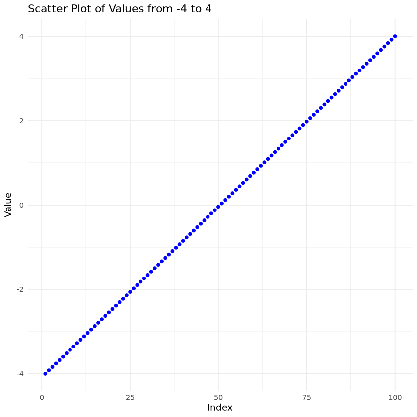

```r
# Generate a vector of 100 values between -4 and 4
n <- 100
x <- seq(-4, 4, length = n)

# Create a data frame for ggplot2
df_raw <- data.frame(Index = 1:n, Value = x)

# Plot using ggplot2
ggplot(df_raw, aes(x = Index, y = Value)) +
  geom_point(color = "blue") +
  labs(
    title = "Scatter Plot of Values from -4 to 4",
    x = "Index",
    y = "Value"
  ) +
  theme_minimal()
```

To find the value of probability density function (pdf) of the Student's t-distribution given a random variable x, use the dt() function in R.

```
Syntax: dt(x, df)

Parameters:
- x is the quantiles vector
- df is the degrees of freedom
```

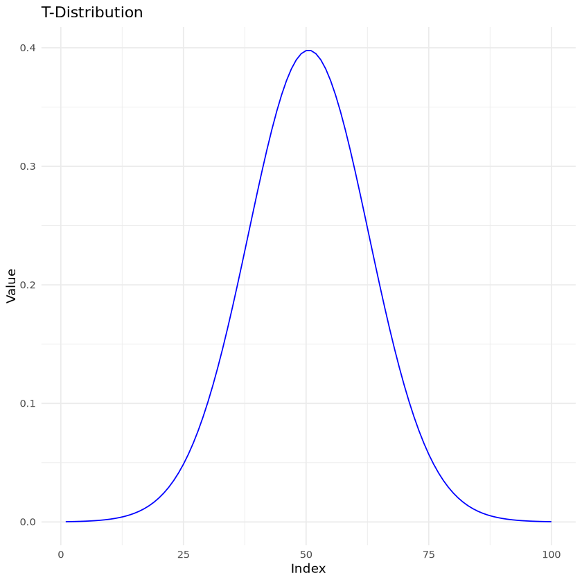

```r
# Simulate the t-distribution
y <- dt(x, df = n - 1)

# Create a data frame for ggplot2
df_T <- data.frame(Index = 1:n, Value = y)

# Create the scatter plot
ggplot(df_T, aes(x = Index, y = Value)) +
  geom_line(color = "blue") +
  labs(
    title = "T-Distribution",
    x = "Index",
    y = "Value"
  ) +
  theme_minimal()
```

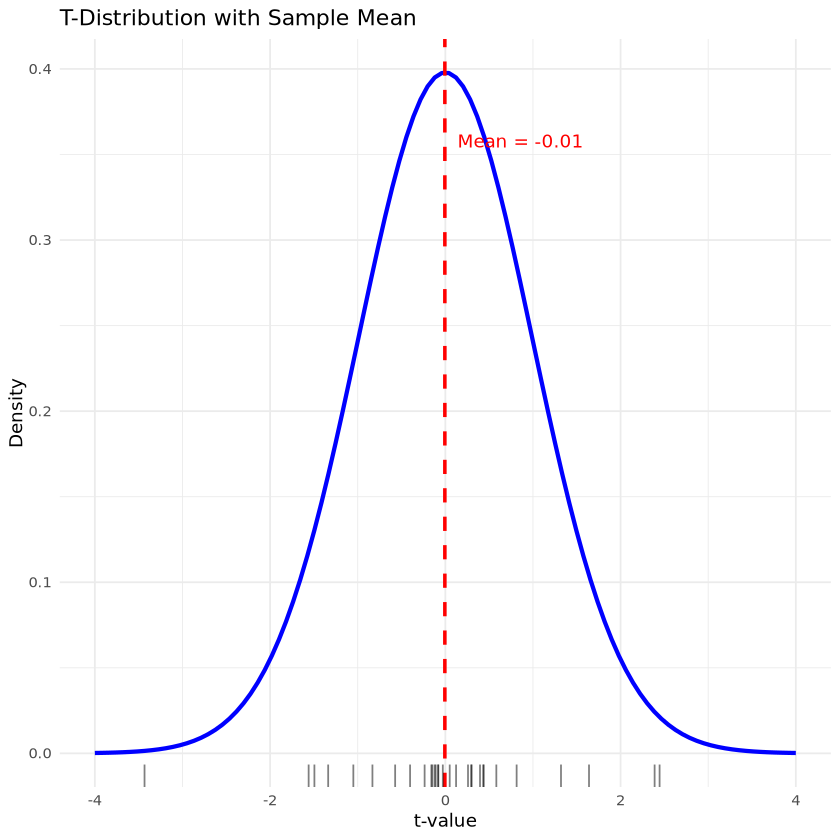

```r
# Step 1: Sample from t-distribution
set.seed(123)
sample_size <- 30
sample_data <- rt(sample_size, df = n-1)
sample_mean <- mean(sample_data)

# Step 2: Plot with rug (horizontal tick marks showing sample values)
ggplot(df_T, aes(x = x, y = y)) +
  geom_line(color = "blue", size = 1.2) +
  geom_vline(xintercept = sample_mean, color = "red", linetype = "dashed", size = 1) +
  geom_rug(data = data.frame(x = sample_data), aes(x = x), inherit.aes = FALSE, sides = "b", color = "black", alpha = 0.5) +
  annotate("text", x = sample_mean, y = max(y)*0.9,
           label = paste0("Mean = ", round(sample_mean, 2)), color = "red", hjust = -0.1) +
  labs(title = "T-Distribution with Sample Mean",
       x = "t-value", y = "Density") +
  theme_minimal()
```

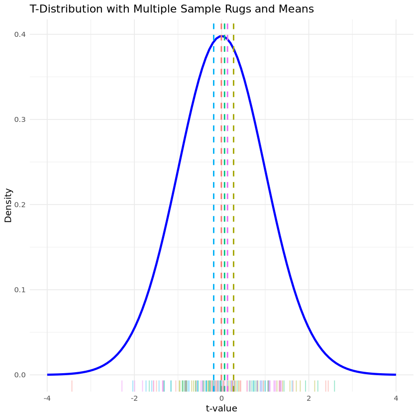

```r
# Step 1: Generate multiple samples
set.seed(123)
sample_size <- 30
n_repeats <- 5

# Store all sample data with sample ID
samples <- lapply(1:n_repeats, function(i) {
  data.frame(Sample = paste0("Sample ", i),
             Value = rt(sample_size, df = n-1))
}) %>% bind_rows()

# Compute means for each sample
sample_means <- samples %>%
  group_by(Sample) %>%
  summarise(mean = mean(Value))

# Step 2: Base plot with t-distribution
p <- ggplot(df_T, aes(x = x, y = y)) +
  geom_line(color = "blue", size = 1.2) +
  labs(title = "T-Distribution with Multiple Sample Rugs and Means",
       x = "t-value", y = "Density") +
  theme_minimal()

# Step 3: Add rugs and means
# We'll loop through each sample group and add them
for (i in seq_len(n_repeats)) {
  sample_name <- paste0("Sample ", i)
  sample_vals <- samples %>% filter(Sample == sample_name)
  sample_mean <- sample_means %>% filter(Sample == sample_name) %>% pull(mean)

  # Add rug and mean line
  p <- p +
    geom_rug(data = sample_vals, aes(x = Value), inherit.aes = FALSE,
             sides = "b", alpha = 0.4, color = scales::hue_pal()(n_repeats)[i]) +
    geom_vline(xintercept = sample_mean, color = scales::hue_pal()(n_repeats)[i],
               linetype = "dashed", size = 0.8)
}

# Print the plot
p
```

The bigger degree of freedom, the closer your T distribution to normal distribution

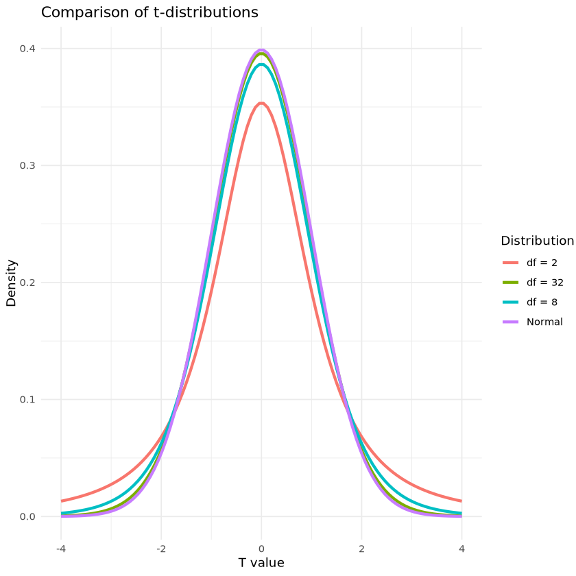

```r
# Create a data frame with all distributions
df <- data.frame(
  x = rep(x, times = 4),
  density = c(
    dt(x, df = 2),
    dt(x, df = 8),
    dt(x, df = 32),
    dnorm(x)
  ),
  distribution = factor(rep(c("df = 2", "df = 8", "df = 32", "Normal"), each = length(x)))
)

# Plot
ggplot(df, aes(x = x, y = density, color = distribution)) +
  geom_line(linewidth = 1.2) +
  labs(
    title = "Comparison of t-distributions",
    x = "T value",
    y = "Density",
    color = "Distribution"
  ) +
  theme_minimal()
```

## 🐟 Investigating Fish Populations Near a Factory

A group of environmental biologists is conducting a study on the possible ecological impact of a local manufacturing plant. The factory is located between two small lakes that are part of the same river system:

- The first lake is **upstream** of the factory and receives no direct runoff from industrial activities.
- The second lake is **downstream** of the factory and could potentially be affected by effluents or waste discharge.

To assess the potential impact, the team collected samples of fish from both lakes. For each fish, they recorded:

- **Length** (in centimeters)
- **Weight** (in grams)

The scientists want to determine whether the fish population in the Downstream lake shows any significant difference in size compared to the Upstream lake. Differences in fish size (length or weight) could be an indicator of environmental stress, food availability, or contamination.

### 1. Exploratory Data Analysis

```r
# Import Dataset
fish_data <- read.csv("../data/fish_data_weight.csv")

# Quick look
head(fish_data)
```

A data.frame: 6 × 3

|  | Lake <chr> | Length_cm <dbl> | Weight_g <dbl> |
| --- | --- | --- | --- |
| 1 | Upstream | 26.3 | 318.7 |
| 2 | Upstream | 27.3 | 347.7 |
| 3 | Upstream | 32.7 | 332.6 |
| 4 | Upstream | 28.2 | 329.6 |
| 5 | Upstream | 28.4 | 311.5 |
| 6 | Upstream | 33.1 | 338.6 |

```r
length_stats <- fish_data %>%
  group_by(Lake) %>%
  summarise(
    mean = mean(Length_cm),
    sd = sd(Length_cm),
    n = n(),
    se = sd / sqrt(n),
    df = n - 1
  )
length_stats
```

A tibble: 2 × 6

| Lake <chr> | mean <dbl> | sd <dbl> | n <int> | se <dbl> | df <dbl> |
| --- | --- | --- | --- | --- | --- |
| Downstream | 28.436 | 2.719451 | 50 | 0.3845884 | 49 |
| Upstream | 28.102 | 2.784028 | 50 | 0.3937210 | 49 |

```r
weight_stats <- fish_data %>%
  group_by(Lake) %>%
  summarise(
    mean = mean(Weight_g),
    sd = sd(Weight_g),
    n = n(),
    se = sd / sqrt(n),
    df = n - 1
  )
weight_stats
```

A tibble: 2 × 6

| Lake <chr> | mean <dbl> | sd <dbl> | n <int> | se <dbl> | df <dbl> |
| --- | --- | --- | --- | --- | --- |
| Downstream | 301.160 | 27.93020 | 50 | 3.949926 | 49 |
| Upstream | 332.382 | 29.67265 | 50 | 4.196347 | 49 |

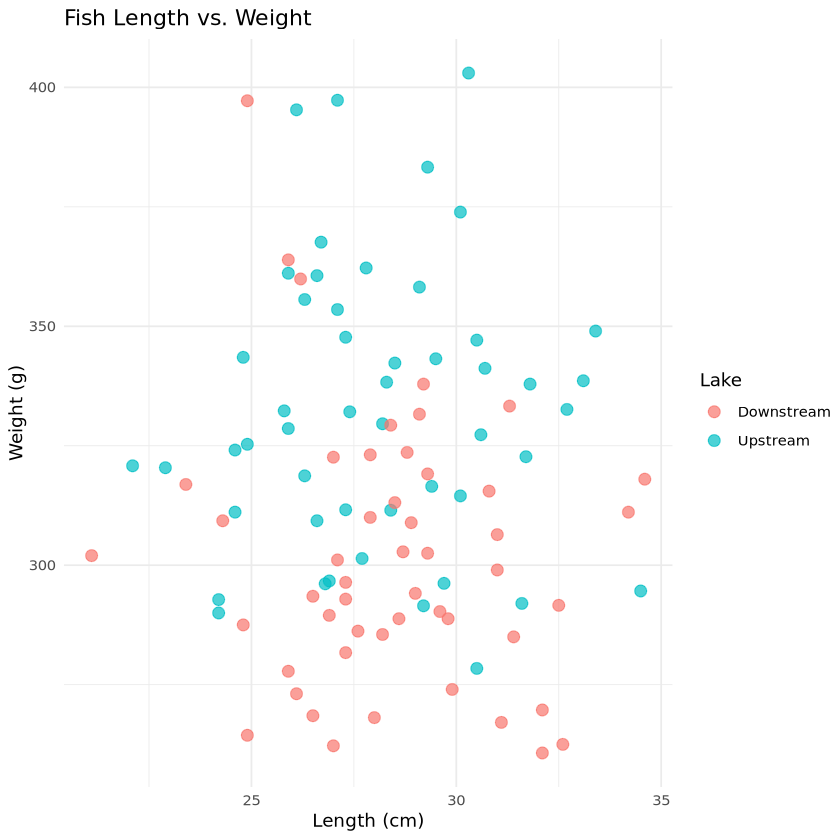

```r
# Visualize using scatter plot to see the distribution
ggplot(fish_data, aes(x = Length_cm, y = Weight_g, color = Lake)) +
  geom_point(size = 3, alpha = 0.7) +
  labs(
    title = "Fish Length vs. Weight",
    x = "Length (cm)",
    y = "Weight (g)",
    color = "Lake"
  ) +
  theme_minimal()
```

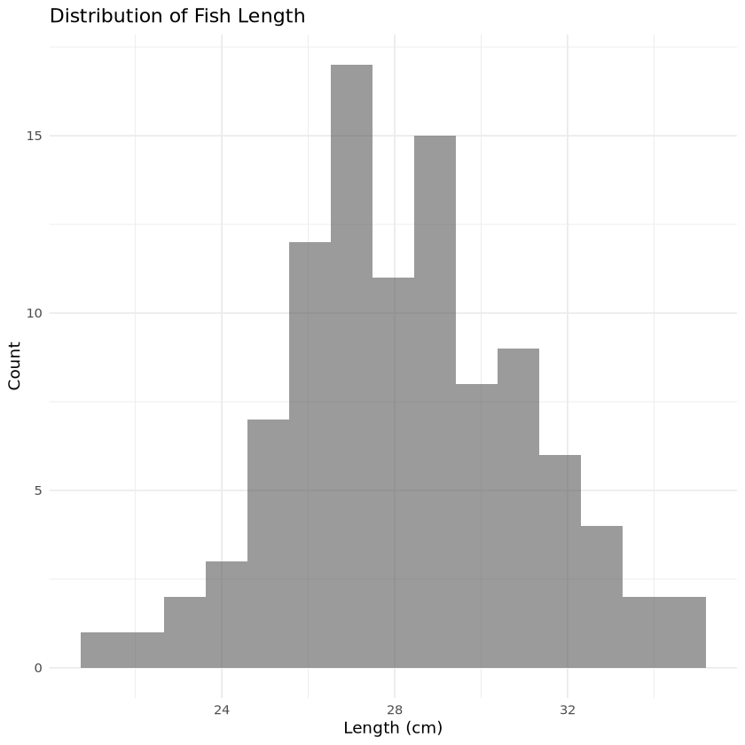

```r
ggplot(fish_data, aes(x = Length_cm)) +
  geom_histogram(position = "identity", alpha = 0.6, bins = 15) +
  labs(title = "Distribution of Fish Length",
       x = "Length (cm)",
       y = "Count") +
  theme_minimal()
```

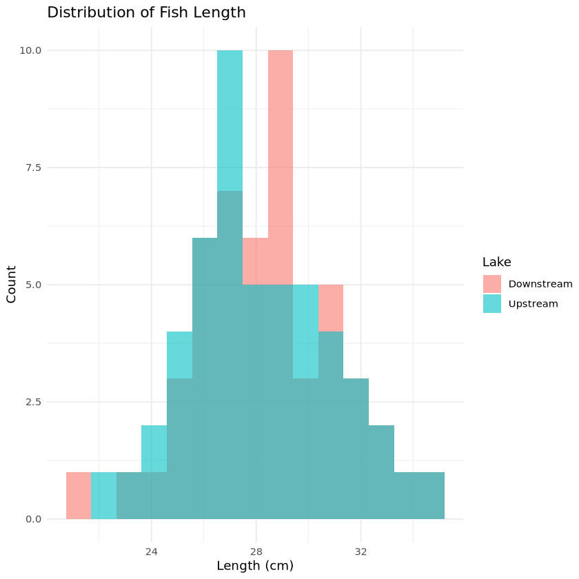

```r
ggplot(fish_data, aes(x = Length_cm, fill = Lake)) +
  geom_histogram(position = "identity", alpha = 0.6, bins = 15) +
  labs(title = "Distribution of Fish Length",
       x = "Length (cm)",
       y = "Count") +
  theme_minimal()
```

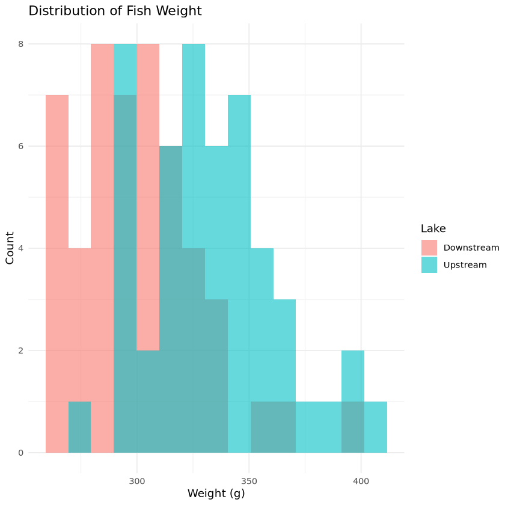

```r
ggplot(fish_data, aes(x = Weight_g, fill = Lake)) +
  geom_histogram(position = "identity", alpha = 0.6, bins = 15) +
  labs(title = "Distribution of Fish Weight",
       x = "Weight (g)",
       y = "Count") +
  theme_minimal()
```

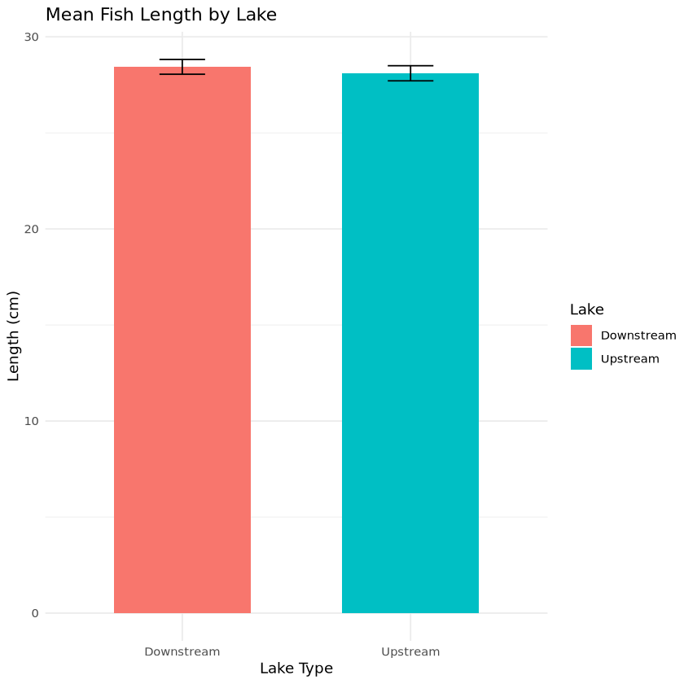

```r
# Summarise data to get mean and standard error per group
weight_summary <- fish_data %>%
  group_by(Lake) %>%
  summarise(
    mean_weight = mean(Length_cm),
    se_weight = sd(Length_cm) / sqrt(n())
  )

# Bar plot with error bars
ggplot(weight_summary, aes(x = Lake, y = mean_weight, fill = Lake)) +
  geom_col(width = 0.6) +
  geom_errorbar(aes(ymin = mean_weight - se_weight,
                    ymax = mean_weight + se_weight),
                width = 0.2) +
  labs(title = "Mean Fish Length by Lake",
       x = "Lake Type",
       y = "Length (cm)") +
  theme_minimal()
```

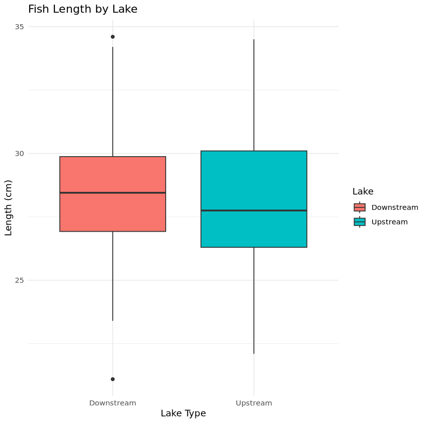

```r
ggplot(fish_data, aes(x = Lake, y = Length_cm, fill = Lake)) +
  geom_boxplot() +
  labs(title = "Fish Length by Lake",
       x = "Lake Type",
       y = "Length (cm)") +
  theme_minimal()
```

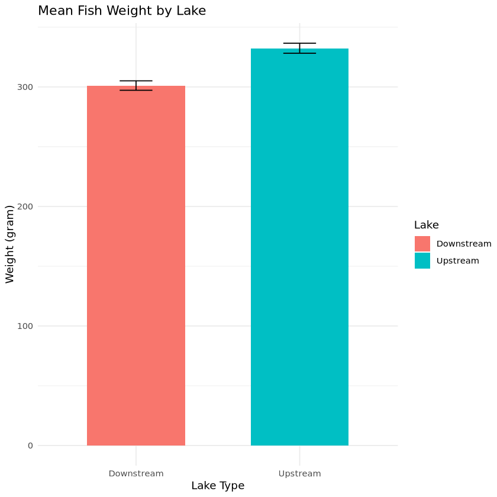

```r
# Summarise data to get mean and standard error per group
weight_summary <- fish_data %>%
  group_by(Lake) %>%
  summarise(
    mean_weight = mean(Weight_g),
    se_weight = sd(Weight_g) / sqrt(n())
  )

# Bar plot with error bars
ggplot(weight_summary, aes(x = Lake, y = mean_weight, fill = Lake)) +
  geom_col(width = 0.6) +
  geom_errorbar(aes(ymin = mean_weight - se_weight,
                    ymax = mean_weight + se_weight),
                width = 0.2) +
  labs(title = "Mean Fish Weight by Lake",
       x = "Lake Type",
       y = "Weight (gram)") +
  theme_minimal()
```

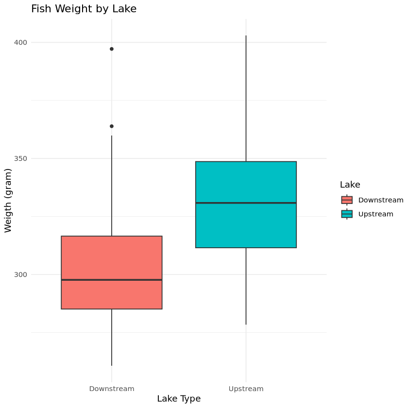

```r
ggplot(fish_data, aes(x = Lake, y = Weight_g, fill = Lake)) +
  geom_boxplot() +
  labs(title = "Fish Weight by Lake",
       x = "Lake Type",
       y = "Weigth (gram)") +
  theme_minimal()
```

### 2.🐟 Independent t-test: Upstream vs Downstream Fish Length

- What you're testing:

  > Whether the mean fish length in the Upstream area is significantly different from the Downstream area.
- We will calculate the t-statistic → the number of standard errors the means are apart.
- Larger `t_value` → stronger evidence of difference.
- The `p` value gives the probability of seeing such a difference by chance.
  > - p < 0.05 → statistically significant difference ✅
  > - p ≥ 0.05 → not statistically significant 🚫
- Cohen's d tells you how big the difference is:

| d | Interpretation |
| --- | --- |
| 0.2 | Small effect |
| 0.5 | Medium effect |
| 0.8+ | Large effect |

> Even if p < 0.05, a small Cohen’s d might mean the difference isn’t practically meaningful.

```r
### Perform an Independent t-test (Manual)

# Create subsets
fish_upstream <- subset(fish_data, Lake == "Upstream")
fish_downstream <- subset(fish_data, Lake == "Downstream")

# Means
mean_up <- mean(fish_upstream$Length_cm)
mean_down <- mean(fish_downstream$Length_cm)
mean_diff <- mean_up - mean_down

# Sample sizes
n_up <- nrow(fish_upstream)
n_down <- nrow(fish_downstream)

# Degrees of freedom
df <- n_up + n_down - 2

# Variances
var_up <- var(fish_upstream$Length_cm)
var_down <- var(fish_downstream$Length_cm)

# Pooled standard error
se_pooled <- sqrt((var_up / n_up) + (var_down / n_down))

### t-test Results

# t-value
t_value <- mean_diff / se_pooled

# Two-tailed p-value
p_value <- 2 * (1 - pt(abs(t_value), df = df))

# Cohen's d (effect size)
sd_up <- sd(fish_upstream$Length_cm)
sd_down <- sd(fish_downstream$Length_cm)
pooled_sd <- (sd_up + sd_down) / 2
cohens_d <- mean_diff / pooled_sd

### Print Results
t_value     # how far apart the means are in SE units
p_value     # is it statistically significant?
cohens_d    # how big is the effect?
```

-0.606847090759995

0.545355751938675

-0.121377773219944

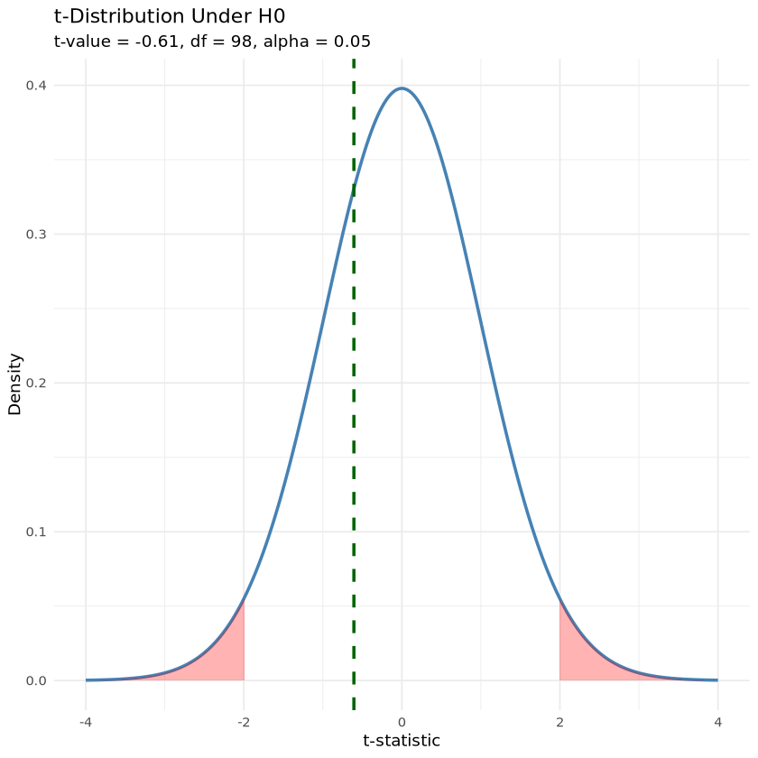

```r
# Use your computed t_value and df
# For example:
# t_value <- 5.87
# df <- 98

alpha <- 0.05
t_crit <- qt(1 - alpha/2, df = df)  # two-tailed

x_vals <- seq(-4, 4, length.out = 300)
y_vals <- dt(x_vals, df = df)

ggplot(data.frame(x = x_vals, y = y_vals), aes(x, y)) +
  geom_line(color = "steelblue", size = 1) +

  # Shade critical regions
  geom_area(data = subset(data.frame(x = x_vals, y = y_vals), x <= -t_crit),
            aes(x = x, y = y), fill = "red", alpha = 0.3) +
  geom_area(data = subset(data.frame(x = x_vals, y = y_vals), x >= t_crit),
            aes(x = x, y = y), fill = "red", alpha = 0.3) +

  # Observed t-value
  geom_vline(xintercept = t_value, color = "darkgreen", linetype = "dashed", size = 1) +

  # Labels
  labs(
    title = "t-Distribution Under H0",
    subtitle = paste0("t-value = ", round(t_value, 2),
                      ", df = ", df,
                      ", alpha = 0.05"),
    x = "t-statistic",
    y = "Density"
  ) +
  theme_minimal()
```

```r
### Independent t-tests, the easy way

# Conduct an independent t-test
t.test(fish_upstream$Length_cm, fish_downstream$Length_cm, var.equal = T)
```

```
	Two Sample t-test

data:  fish_upstream$Length_cm and fish_downstream$Length_cm
t = -0.60685, df = 98, p-value = 0.5454
alternative hypothesis: true difference in means is not equal to 0
95 percent confidence interval:
 -1.4262226  0.7582226
sample estimates:
mean of x mean of y
   28.102    28.436
```

```r
### Independent t-tests, the easy way

# Run t-test and store the result
t_result <- t.test(fish_upstream$Weight_g, fish_downstream$Weight_g, var.equal = TRUE)

# Extract t-value and degrees of freedom
t_value <- t_result$statistic  # this is named "t"
df <- t_result$parameter       # this is named "df"
```

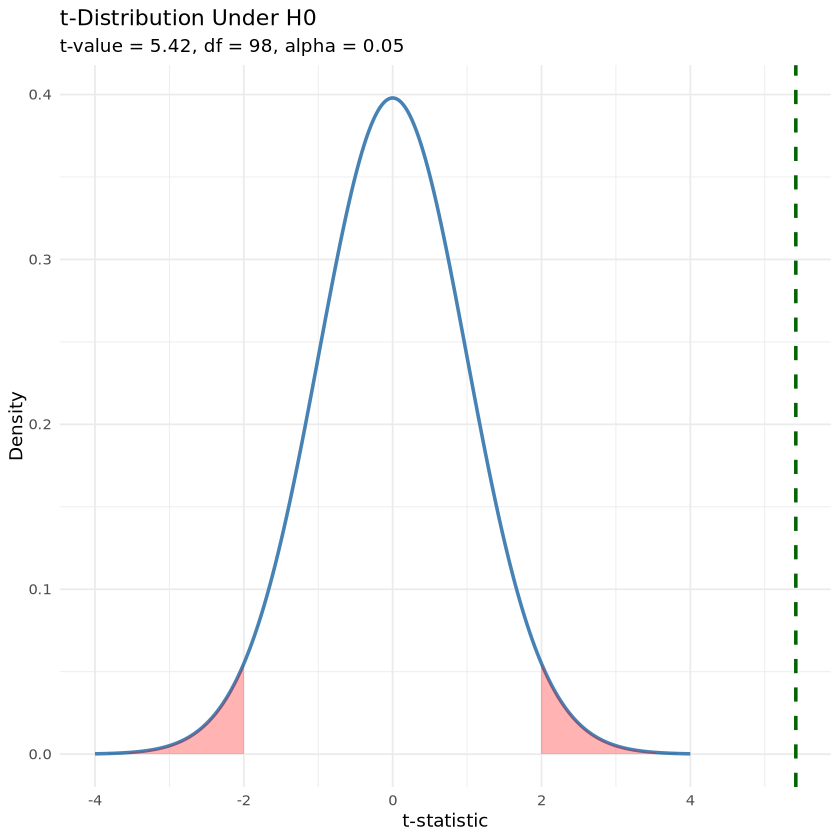

```r
# Use your computed t_value and df
# For example:
# t_value <- 5.87
# df <- 98

alpha <- 0.05
t_crit <- qt(1 - alpha/2, df = df)  # two-tailed

x_vals <- seq(-4, 4, length.out = 300)
y_vals <- dt(x_vals, df = df)

ggplot(data.frame(x = x_vals, y = y_vals), aes(x, y)) +
  geom_line(color = "steelblue", size = 1) +

  # Shade critical regions
  geom_area(data = subset(data.frame(x = x_vals, y = y_vals), x <= -t_crit),
            aes(x = x, y = y), fill = "red", alpha = 0.3) +
  geom_area(data = subset(data.frame(x = x_vals, y = y_vals), x >= t_crit),
            aes(x = x, y = y), fill = "red", alpha = 0.3) +

  # Observed t-value
  geom_vline(xintercept = t_value, color = "darkgreen", linetype = "dashed", size = 1) +

  # Labels
  labs(
    title = "t-Distribution Under H0",
    subtitle = paste0("t-value = ", round(t_value, 2),
                      ", df = ", df,
                      ", alpha = 0.05"),
    x = "t-statistic",
    y = "Density"
  ) +
  theme_minimal()
```